# Modelagem Clínica e Validação Estatística

Matheus Assis de Oliveira

2026-07-03

# Introdução

Este projeto consolida dois estudos de modelagem clínica supervisionada: classificação de diabetes e classificação de doença cardíaca. A ênfase não está apenas em acurácia, mas em validação, discriminação, calibração, interpretabilidade e limites de uso.

# Motivação

# Dados e método

Foram integradas duas bases clínicas tabulares já tratadas. Em cada estudo foram comparados modelos logísticos e árvores de decisão, com validação holdout e métricas de classificação.

O pipeline foi:

1. organização das bases limpas e métricas finais;
2. consolidação de resultados de diabetes e doença cardíaca;
3. comparação de métricas de validação;
4. análise de curva ROC;
5. avaliação de calibração;
6. leitura de importância das variáveis;
7. publicação em dashboard, relatório HTML e PDF.

# Resultados descritivos

| Indicador | Resultado |
| --- | --- |
| Projetos integrados | 2,000 |
| Registros na base de diabetes | 768,000 |
| Registros na base cardíaca | 303,000 |
| Melhor AUC - diabetes | 91,6% |
| Melhor AUC - doença cardíaca | 86,3% |
| Acurácia holdout - diabetes | 83,8% |
| Acurácia holdout - doença cardíaca | 80,3% |
| Sensibilidade - diabetes | 64,8% |
| Sensibilidade - doença cardíaca | 87,9% |

# Métricas de validação

| Projeto | Modelo | Acurácia | Sensibilidade | Especificidade | Precisão | F1 | AUC | VP | FP | VN | FN |
| --- | --- | --- | --- | --- | --- | --- | --- | --- | --- | --- | --- |
| Diabetes | logistic | 83,8% | 64,8% | 94,0% | 85,4% | 73,7% | 91,6% | 35 | 6 | 94 | 19 |
| Diabetes | tree | 77,3% | 72,2% | 80,0% | 66,1% | 69,0% | 84,5% | 39 | 20 | 80 | 15 |
| Doença cardíaca | logistic | 80,3% | 87,9% | 71,4% | 78,4% | 82,9% | 86,3% | 29 | 8 | 20 | 4 |
| Doença cardíaca | tree | 73,8% | 69,7% | 78,6% | 79,3% | 74,2% | 74,6% | 23 | 6 | 22 | 10 |

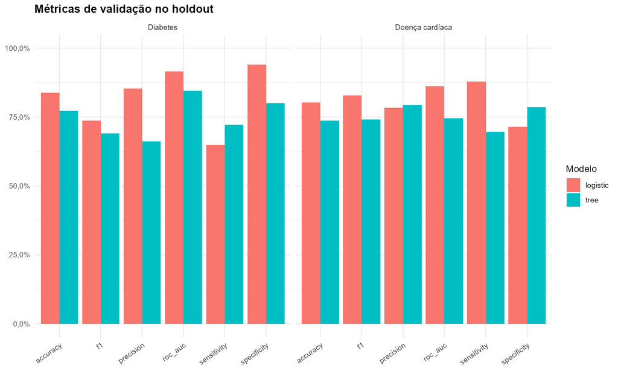

# Discriminação

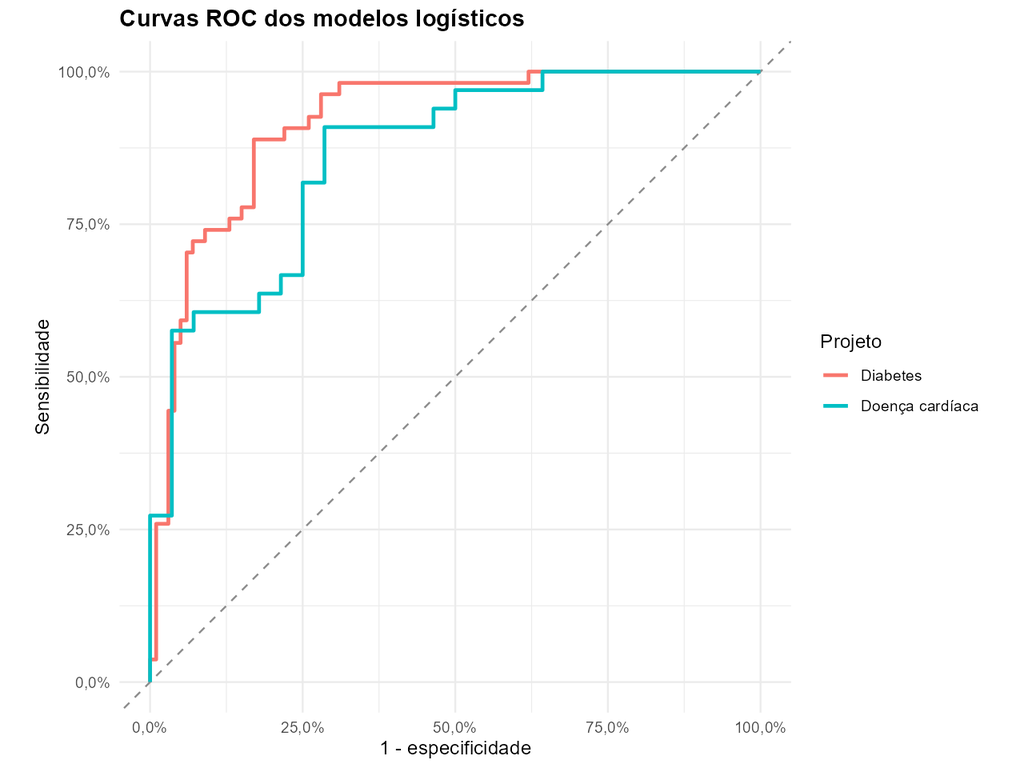

A curva ROC mostra a capacidade de discriminar positivos e negativos ao variar o limiar de decisão. O modelo de diabetes apresenta AUC mais alta que o modelo cardíaco, mas ambos exigem leitura conjunta com sensibilidade e especificidade.

# Calibração

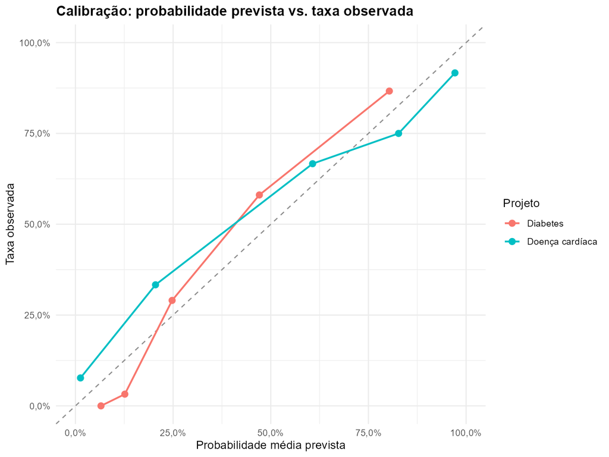

Calibração compara probabilidade prevista e frequência observada. Esse ponto é essencial em modelos clínicos porque probabilidades mal calibradas podem induzir priorização inadequada mesmo quando a AUC é razoável.

# Interpretabilidade

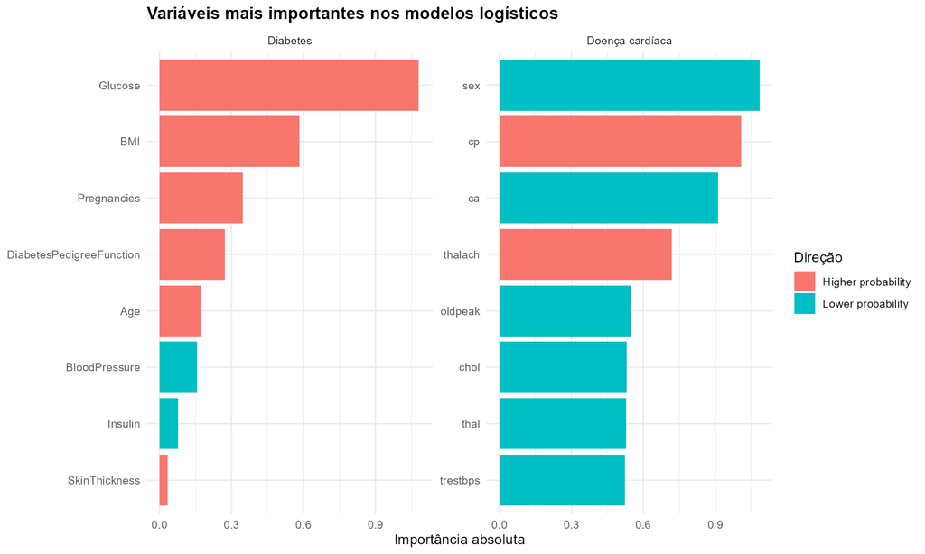

As variáveis mais relevantes ajudam a explicar o comportamento dos modelos e a identificar sinais consistentes com conhecimento clínico. Essa leitura não transforma coeficiente em causalidade.

# Desfechos e matriz de confusão

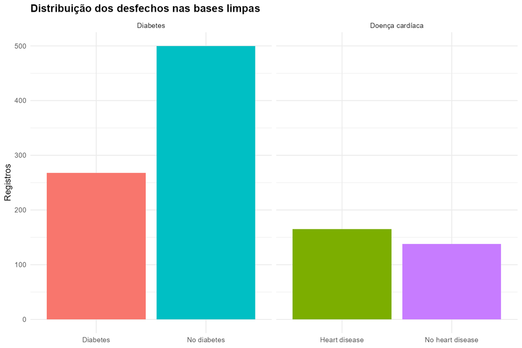

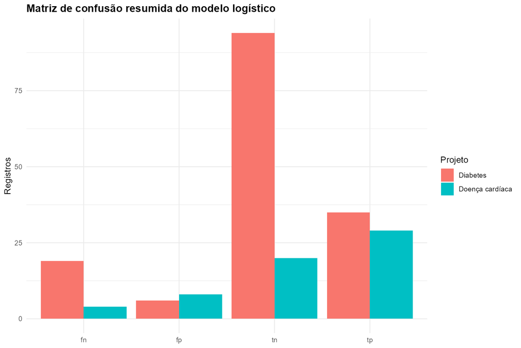

# Dashboard

O dashboard executivo está em `docs/modelagem_clinica_dashboard.html`. Ele resume métricas, ROC, calibração, importância de variáveis, distribuição dos desfechos e matriz de confusão.

# Limitações

As bases são tabulares e de demonstração. Os modelos não devem ser usados para decisão clínica real sem validação externa, auditoria de viés, avaliação de calibração em população-alvo, governança de dados e aprovação institucional. O projeto é uma peça de portfólio profissional de análise e validação, não um dispositivo médico.

# Conclusão

O projeto demonstra um fluxo completo e comunicável de modelagem clínica: preparação dos dados, comparação de modelos, validação, calibração, interpretação e publicação dos resultados. O valor está em mostrar maturidade analítica, não apenas treinar um classificador.